# Statistical Analysis of MEA data.

Federico Menéndez Conde

2023-03-15

Hereby, data generated in the “Transversal Analysis of MEA data” document is analysed.

First, we load the database *MEA_segments* that we will use to perform the study. This is the list of the 30 second periods with more movement in the MEA videos. The criterion used is for the movement in the period to be higher than the median, and that this has to hold for both subjects (patient and therapist).

The database has 857 observations of 19 variables.

Below, we show the entries of a few observations in the database.

| id | video | zone | num_period | start | end | mov_patient | mov_therapist | mov_medio | spearman_max | lag_spearman_max | spearman_min | lag_spearman_min | leads | sex | type | se_mueve_mas | correl | delta_mov |
| --- | --- | --- | --- | --- | --- | --- | --- | --- | --- | --- | --- | --- | --- | --- | --- | --- | --- | --- |
| 1 | Vid0 | head | 6 | 2.7 | 3.2 | 686.4200 | 140.28007 | 413.3500 | 0.3662534 | -4.60 | -0.4565995 | 4.77 | therapist | M | Diagnosed | patient | negative | -546.1399 |
| 2 | Vid0 | head | 15 | 7.2 | 7.7 | 615.9966 | 307.45456 | 461.7256 | 0.4063359 | -16.63 | -0.6091974 | -0.63 | patient | M | Diagnosed | patient | negative | -308.5420 |
| 3 | Vid0 | head | 18 | 8.7 | 9.2 | 944.5618 | 118.37419 | 531.4680 | 0.2545730 | -8.43 | -0.3361703 | 1.77 | therapist | M | Diagnosed | patient | negative | -826.1876 |
| 4 | Vid0 | head | 19 | 9.2 | 9.7 | 839.2966 | 88.68341 | 463.9900 | 0.2845798 | 12.73 | -0.2045654 | -5.10 | therapist | M | Diagnosed | patient | positive | -750.6132 |
| 5 | Vid0 | head | 28 | 13.7 | 14.2 | 803.9494 | 184.00915 | 493.9793 | 0.2616083 | 9.13 | -0.6135124 | -0.33 | patient | M | Diagnosed | patient | negative | -619.9403 |
| 6 | Vid0 | head | 31 | 15.2 | 15.7 | 2363.3189 | 114.59967 | 1238.9593 | 0.2811299 | 14.57 | -0.3964339 | 8.93 | therapist | M | Diagnosed | patient | negative | -2248.7192 |
| 7 | Vid0 | head | 39 | 19.2 | 19.7 | 837.7461 | 105.86044 | 471.8033 | 0.1979408 | -13.67 | -0.3991757 | 4.27 | therapist | M | Diagnosed | patient | negative | -731.8856 |
| 8 | Vid0 | head | 44 | 21.7 | 22.2 | 1119.5510 | 115.68696 | 617.6190 | 0.2970029 | 3.67 | -0.4475045 | -3.07 | patient | M | Diagnosed | patient | negative | -1003.8640 |
| 9 | Vid0 | head | 45 | 22.2 | 22.7 | 1550.8191 | 134.21767 | 842.5184 | 0.2728100 | -0.73 | -0.3725645 | 11.30 | therapist | M | Diagnosed | patient | negative | -1416.6015 |
| 10 | Vid0 | head | 49 | 24.2 | 24.7 | 745.1992 | 95.84044 | 420.5198 | 0.5978312 | -5.50 | -0.2927766 | 1.43 | patient | M | Diagnosed | patient | positive | -649.3588 |

Take a look into the lags where the maximum positive and negative cross correlations are found.

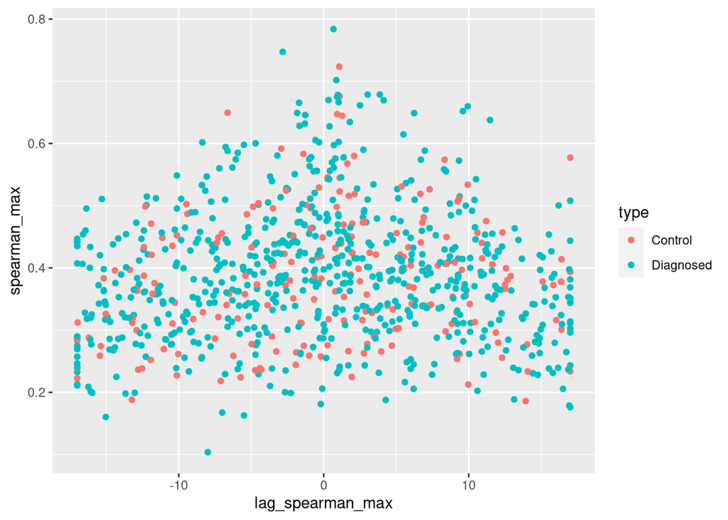

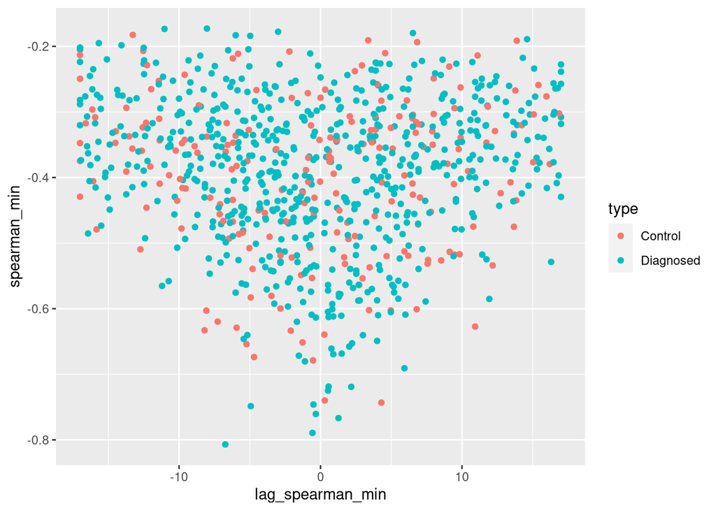

Split the database in two: database *MEA_segments_pos* and *MEA_segments_neg* according with the type of correlation found (positive or negative). Remove the entries with lags small (less than a quarter of a second). Also, keep only the entries with moderate and high cross correlations (absolute values above 0.35).

With such criteria, there are 347 with positive correlation and 379 with negative correlation. Visualize the lags

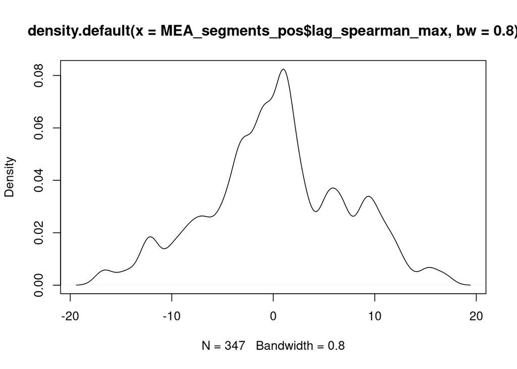

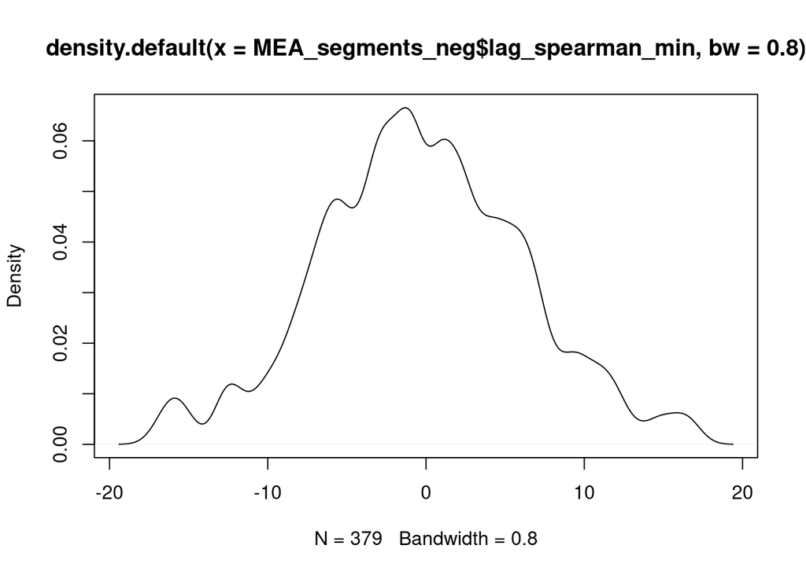

And the lags with the value of the correlation

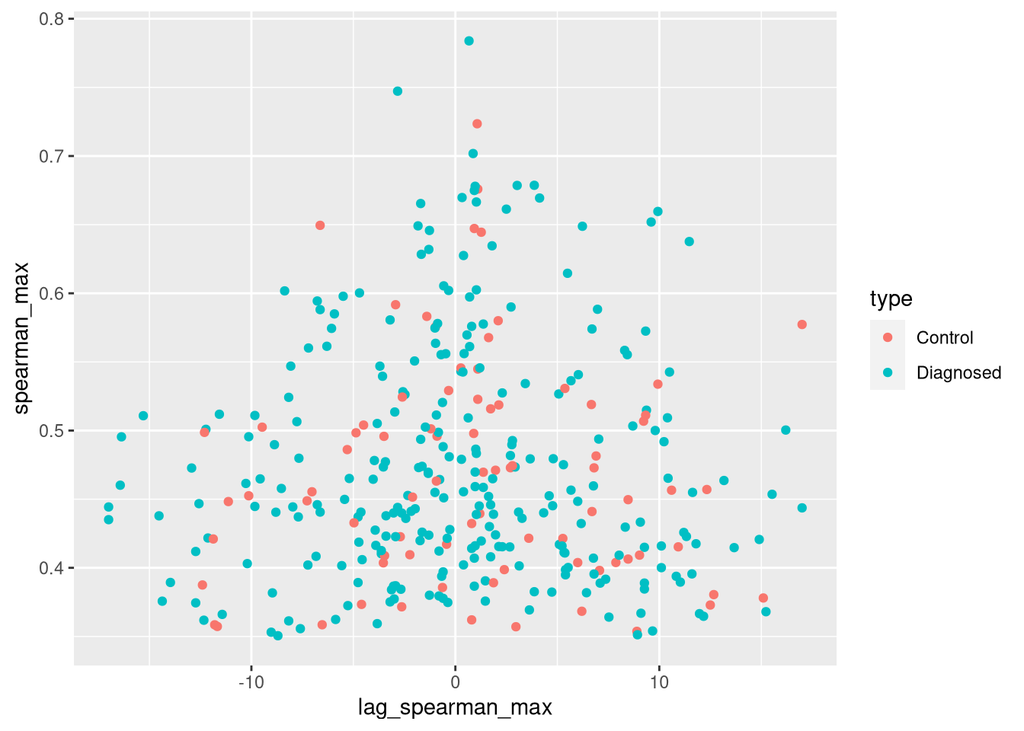

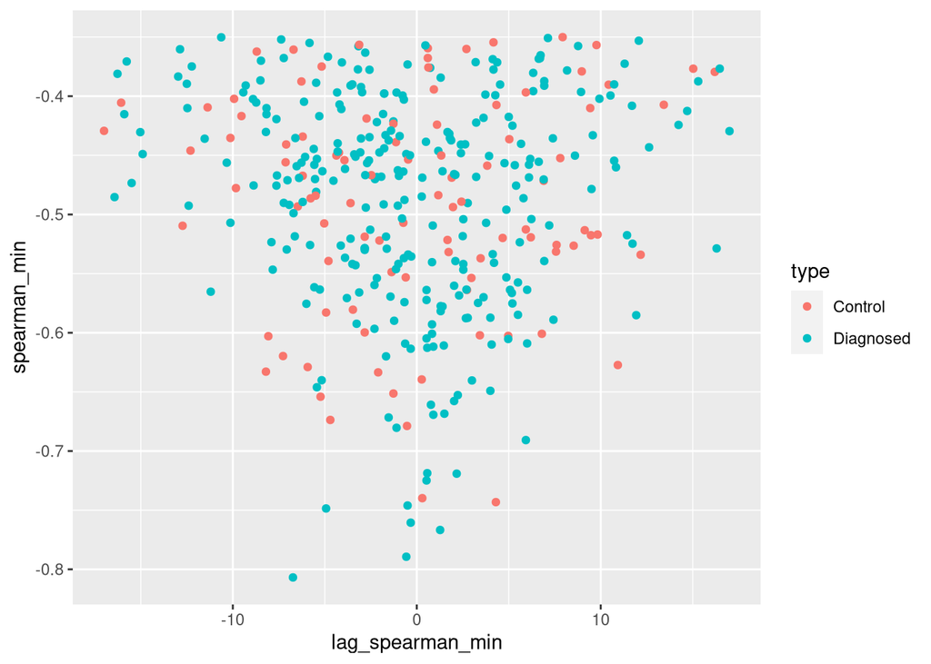

An overview of the variables of interest, classified into diagnosed subjects vs control subjects.

| type | observed | mean_max_correlation | sd_correlation | mean_lag | sd_lag | mean_therapist_mov | mean_patient_mov |
| --- | --- | --- | --- | --- | --- | --- | --- |
| Control | 209 | 0.3823734 | 0.1029235 | 0.0522967 | 8.714340 | 547.3686 | 261.1474 |
| Diagnosed | 648 | 0.3892188 | 0.1069351 | -0.1227006 | 9.144172 | 325.1289 | 294.3064 |

[output not shown]

Chi-squared tests for independence for type (Control/Diagnosed) vs leading (Patient/Therapist)

All subjects. Positive correlations. Who leads.

```
##
##             patient therapist
##   Control        34        47
##   Diagnosed     132       134
```

```
##
##  Pearson's Chi-squared test with Yates' continuity correction
##
## data:  MEA_segments_pos$type and MEA_segments_pos$leads
## X-squared = 1.1654, df = 1, p-value = 0.2804
```

```
##
##  Fisher's Exact Test for Count Data
##
## data:  MEA_segments_pos$type and MEA_segments_pos$leads
## p-value = 0.2539
## alternative hypothesis: true odds ratio is not equal to 1
## 95 percent confidence interval:
##  0.4291171 1.2494836
## sample estimates:
## odds ratio
##  0.7350224
```

All subjects. Negative correlations. Who leads.

```
##
##             patient therapist
##   Control        49        48
##   Diagnosed     151       131
```

```
##
##  Pearson's Chi-squared test with Yates' continuity correction
##
## data:  MEA_segments_neg$type and MEA_segments_neg$leads
## X-squared = 0.15828, df = 1, p-value = 0.6907
```

```
##
##  Fisher's Exact Test for Count Data
##
## data:  MEA_segments_neg$type and MEA_segments_neg$leads
## p-value = 0.6382
## alternative hypothesis: true odds ratio is not equal to 1
## 95 percent confidence interval:
##  0.5435306 1.4440936
## sample estimates:
## odds ratio
##  0.8859093
```

All subjects. Both signs. Welch t-tests for means of the lags.

[output not shown]

```
##
##  Welch Two Sample t-test
##
## data:  diagnosed_list_neg$lag_spearman_max and control_list_neg$lag_spearman_max
## t = 0.14884, df = 177.17, p-value = 0.8818
## alternative hypothesis: true difference in means is not equal to 0
## 95 percent confidence interval:
##  -2.211964  2.572847
## sample estimates:
##  mean of x  mean of y
## -0.1146099 -0.2950515
```

All subjects. Is the correlation positive or negative.

```
##
##             negative positive
##   Control        117       92
##   Diagnosed      327      321
```

```
##
##  Pearson's Chi-squared test with Yates' continuity correction
##
## data:  MEA_segments$type and MEA_segments$correl
## X-squared = 1.7125, df = 1, p-value = 0.1907
```

```
##
##  Fisher's Exact Test for Count Data
##
## data:  MEA_segments$type and MEA_segments$correl
## p-value = 0.1763
## alternative hypothesis: true odds ratio is not equal to 1
## 95 percent confidence interval:
##  0.9016994 1.7309294
## sample estimates:
## odds ratio
##   1.248077
```

Same analysis, segmenting by sex of the patient.

Males. Positive correlation. Who leads.

```
##
##             patient therapist
##   Control        15        29
##   Diagnosed      39        35
```

```
##
##  Pearson's Chi-squared test with Yates' continuity correction
##
## data:  MEA_segments_pos_m$type and MEA_segments_pos_m$leads
## X-squared = 3.1376, df = 1, p-value = 0.07651
```

```
##
##  Fisher's Exact Test for Count Data
##
## data:  MEA_segments_pos_m$type and MEA_segments_pos_m$leads
## p-value = 0.05783
## alternative hypothesis: true odds ratio is not equal to 1
## 95 percent confidence interval:
##  0.1978347 1.0716094
## sample estimates:
## odds ratio
##  0.4672469
```

Males. Negative correlation. Who leads.

```
##
##             patient therapist
##   Control        17        13
##   Diagnosed      26        37
```

```
##
##  Pearson's Chi-squared test with Yates' continuity correction
##
## data:  MEA_segments_neg_m$type and MEA_segments_neg_m$leads
## X-squared = 1.3682, df = 1, p-value = 0.2421
```

```
##
##  Fisher's Exact Test for Count Data
##
## data:  MEA_segments_neg_m$type and MEA_segments_neg_m$leads
## p-value = 0.1873
## alternative hypothesis: true odds ratio is not equal to 1
## 95 percent confidence interval:
##  0.7069899 4.9380497
## sample estimates:
## odds ratio
##   1.848362
```

Males. Is the correlation positive or negative.

```
##
##             negative positive
##   Control         37       49
##   Diagnosed       73       89
```

```
##
##  Pearson's Chi-squared test with Yates' continuity correction
##
## data:  MEA_segments_m$type and MEA_segments_m$correl
## X-squared = 0.03002, df = 1, p-value = 0.8624
```

```
##
##  Fisher's Exact Test for Count Data
##
## data:  MEA_segments_m$type and MEA_segments_m$correl
## p-value = 0.7894
## alternative hypothesis: true odds ratio is not equal to 1
## 95 percent confidence interval:
##  0.5240661 1.6114022
## sample estimates:
## odds ratio
##  0.9209165
```

Females. Positive correlations. Who leads.

```
##
##             patient therapist
##   Control        19        18
##   Diagnosed      93        99
```

```
##
##  Pearson's Chi-squared test with Yates' continuity correction
##
## data:  MEA_segments_pos_f$type and MEA_segments_pos_f$leads
## X-squared = 0.021048, df = 1, p-value = 0.8846
```

```
##
##  Fisher's Exact Test for Count Data
##
## data:  MEA_segments_pos_f$type and MEA_segments_pos_f$leads
## p-value = 0.8578
## alternative hypothesis: true odds ratio is not equal to 1
## 95 percent confidence interval:
##  0.5221579 2.4235544
## sample estimates:
## odds ratio
##   1.123083
```

Females. Negative correlation. Who leads.

[output not shown]

[output not shown]

[output not shown]

Females. Is the correlation positive or negative.

```
##
##             negative positive
##   Control         80       43
##   Diagnosed      254      232
```

```
##
##  Pearson's Chi-squared test with Yates' continuity correction
##
## data:  MEA_segments_f$type and MEA_segments_f$correl
## X-squared = 5.9651, df = 1, p-value = 0.01459
```

```
##
##  Fisher's Exact Test for Count Data
##
## data:  MEA_segments_f$type and MEA_segments_f$correl
## p-value = 0.01134
## alternative hypothesis: true odds ratio is not equal to 1
## 95 percent confidence interval:
##  1.106928 2.630415
## sample estimates:
## odds ratio
##    1.69785
```